# R4DS_27_re_express_some_homework_as_an_R_Notebook

# Imports the State Declaration of Session of the Civil War as

# Tidy Tibble

```r
rm(list = ls())
```

TMWR 2: Tidy text format and Civil War History II

**VIRGINIA**

```
THE SECESSION ORDINANCE.
```

AN ORDINANCE TO REPEAL THE RATIFICATION OF THE CONSTITUTION OF THE UNITED STATES OF AMERICA BY THE STATE OF VIRGINIA, AND TO RESUME ALL THE RIGHTS AND POWERS GRANTED UNDER SAID CONSTITUTION.

The people of Virginia, in their ratification of the Constitution of the United States of America, adopted by them in Convention on the twenty-fifth day of June, in the year of our Lord one thousand seven hundred and eighty-eight, having declared that the powers granted under the said Constitution were derived from the people of the United States, and might be resumed whensoever the same should be perverted to their injury and oppression; and the Federal Government, having perverted said powers, not only to the injury of the people of Virginia, but to the oppression of the Southern Slaveholding States.

Now, therefore, we, the people of Virginia, do declare and ordain that the ordinance adopted by the people of this State in Convention, on the twenty-fifth day of June, eighty-eight, whereby the Constitution of the United States of America was ratified, and all acts of the General Assembly of this State, ratifying or adopting amendments to said Constitution, are hereby repealed and abrogated; that the Union between the State of Virginia and the other States under the Constitution aforesaid, is hereby dissolved, and that the State of Virginia is in the full possession and exercise of all the rights of sovereignty which belong and appertain to a free and independent State. And they do further declare that the said Constitution of the United States of America is no longer binding on any of the citizens of this State.

This ordinance shall take effect and be an act of this day when ratified by a majority of the votes of the people of this State, cast at a poll to be taken thereon on the fourth Thursday in May next, in pursuance of a schedule to be hereafter enacted.

Done in Convention, in the city of Richmond, on the 17th day of April, in the year of our Lord one thousand eight hundred and sixty-one, and in the eighty-fifth year of the Commonwealth of Virginia.

JNO. L. EUBANK, Secretary of Convention

**TEXAS**

A Declaration of the Causes which Impel the State of Texas to Secede from the Federal Union.

The government of the United States, by certain joint resolutions, bearing date the 1st day of March, in the year A.D. 1845, proposed to the Republic of Texas, then *a free, sovereign and independent nation* [emphasis in the original], the annexation of the latter to the former, as one of the co-equal states thereof,

The people of Texas, by deputies in convention assembled, on the fourth day of July of the same year, assented to and accepted said proposals and formed a constitution for the proposed State, upon which on the 29th day of December in the same year, said State was formally admitted into the Confederated Union.

Texas abandoned her separate national existence and consented to become one of the Confederated Union to promote her welfare, insure domestic tranquility and secure more substantially the blessings of peace and liberty to her people. She was received into the confederacy with her own constitution, under the guarantee of the federal constitution and the compact of annexation, that she should enjoy these blessings. She was received as a commonwealth holding, maintaining and protecting the institution known as negro slavery– the servitude of the African to the white race within her limits– a relation that had existed from the first settlement of her wilderness by the white race, and which her people intended should exist in all future time. Her institutions and geographical position established the strongest ties between her and other slave-holding States of the confederacy. Those ties have been strengthened by association. But what has been the course of the government of the United States, and of the people and authorities of the non-slave-holding States, since our connection with them?

The controlling majority of the Federal Government, under various pretences and disguises, has so administered the same as to exclude the citizens of the Southern States, unless under odious and unconstitutional restrictions, from all the immense territory owned in common by all the States on the Pacific Ocean, for the avowed purpose of acquiring sufficient power in the common government to use it as a means of destroying the institutions of Texas and her sister slaveholding States.

By the disloyalty of the Northern States and their citizens and the imbecility of the Federal Government, infamous combinations of incendiaries and outlaws have been permitted in those States and the common territory of Kansas to trample upon the federal laws, to war upon the lives and property of Southern citizens in that territory, and finally, by violence and mob law, to usurp the possession of the same as exclusively the property of the Northern States.

The Federal Government, while but partially under the control of these our unnatural and sectional enemies, has for years almost entirely failed to protect the lives and property of the people of Texas against the Indian savages on our border, and more recently against the murderous forays of banditti from the neighboring territory of Mexico; and when our State government has expended large amounts for such purpose, the Federal Government has refuse reimbursement therefor, thus rendering our condition more insecure and harassing than it was during the existence of the Republic of Texas.

These and other wrongs we have patiently borne in the vain hope that a returning sense of justice and humanity would induce a different course of administration.

When we advert to the course of individual non-slave-holding States, and that a majority of their citizens, our grievances assume far greater magnitude.

The States of Maine, Vermont, New Hampshire, Connecticut, Rhode Island, Massachusetts, New York, Pennsylvania, Ohio, Wisconsin, Michigan and Iowa, by solemn legislative enactments, have deliberately, directly or indirectly violated the 3rd clause of the 2nd section of the 4th article [the fugitive slave clause] of the federal constitution, and laws passed in pursuance thereof; thereby annulling a material provision of the compact, designed by its framers to perpetuate the amity between the members of the confederacy and to secure the rights of the slave-holding States in their domestic institutions– a provision founded in justice and wisdom, and without the enforcement of which the compact fails to accomplish the object of its creation. Some of those States have imposed high fines and degrading penalties upon any of their citizens or officers who may carry out in good faith that provision of the compact, or the federal laws enacted in accordance therewith.

In all the non-slave-holding States, in violation of that good faith and comity which should exist between entirely distinct nations, the people have formed themselves into a great sectional party, now strong enough in numbers to control the affairs of each of those States, based upon an unnatural feeling of hostility to these Southern States and their beneficent and patriarchal system of African slavery, proclaiming the debasing doctrine of equality of all men, irrespective of race or color– a doctrine at war with nature, in opposition to the experience of mankind, and in violation of the plainest revelations of Divine Law. They demand the abolition of negro slavery throughout the confederacy, the recognition of political equality between the white and negro races, and avow their determination to press on their crusade against us, so long as a negro slave remains in these States.

For years past this abolition organization has been actively sowing the seeds of discord through the Union, and has rendered the federal congress the arena for spreading firebrands and hatred between the slave-holding and non-slave-holding States.

By consolidating their strength, they have placed the slave-holding States in a hopeless minority in the federal congress, and rendered representation of no avail in protecting Southern rights against their exactions and encroachments. They have proclaimed, and at the ballot box sustained, the revolutionary doctrine that there is a ‘higher law’ than the constitution and laws of our Federal Union, and virtually that they will disregard their oaths and trample upon our rights.

They have for years past encouraged and sustained lawless organizations to steal our slaves and prevent their recapture, and have repeatedly murdered Southern citizens while lawfully seeking their rendition.

They have invaded Southern soil and murdered unoffending citizens, and through the press their leading men and a fanatical pulpit have bestowed praise upon the actors and assassins in these crimes, while the governors of several of their States have refused to deliver parties implicated and indicted for participation in such offenses, upon the legal demands of the States aggrieved.

They have, through the mails and hired emissaries, sent seditious pamphlets and papers among us to stir up servile insurrection and bring blood and carnage to our firesides.

They have sent hired emissaries among us to burn our towns and distribute arms and poison to our slaves for the same purpose.

They have impoverished the slave-holding States by unequal and partial legislation, thereby enriching themselves by draining our substance.

They have refused to vote appropriations for protecting Texas against ruthless savages, for the sole reason that she is a slave-holding State.

And, finally, by the combined sectional vote of the seventeen non-slave-holding States, they have elected as president and vice-president of the whole confederacy two men whose chief claims to such high positions are their approval of these long continued wrongs, and their pledges to continue them to the final consummation of these schemes for the ruin of the slave-holding States.

In view of these and many other facts, it is meet that our own views should be distinctly proclaimed.

We hold as undeniable truths that the governments of the various States, and of the confederacy itself, were established exclusively by the white race, for themselves and their posterity; that the African race had no agency in their establishment; that they were rightfully held and regarded as an inferior and dependent race, and in that condition only could their existence in this country be rendered beneficial or tolerable.

That in this free government *all white men are and of right ought to be entitled to equal civil and political rights* [emphasis in the original]; that the servitude of the African race, as existing in these States, is mutually beneficial to both bond and free, and is abundantly authorized and justified by the experience of mankind, and the revealed will of the Almighty Creator, as recognized by all Christian nations; while the destruction of the existing relations between the two races, as advocated by our sectional enemies, would bring inevitable calamities upon both and desolation upon the fifteen slave-holding states.

By the secession of six of the slave-holding States, and the certainty that others will speedily do likewise, Texas has no alternative but to remain in an isolated connection with the North, or unite her destinies with the South.

For these and other reasons, solemnly asserting that the federal constitution has been violated and virtually abrogated by the several States named, seeing that the federal government is now passing under the control of our enemies to be diverted from the exalted objects of its creation to those of oppression and wrong, and realizing that our own State can no longer look for protection, but to God and her own sons– We the delegates of the people of Texas, in Convention assembled, have passed an ordinance dissolving all political connection with the government of the United States of America and the people thereof and confidently appeal to the intelligence and patriotism of the freemen of Texas to ratify the same at the ballot box, on the 23rd day of the present month.

Adopted in Convention on the 2nd day of Feby, in the year of our Lord one thousand eight hundred and sixty-one and of the independence of Texas the twenty-fifth.

**SOUTH CAROLINA**

Declaration of the Immediate Causes Which Induce and Justify the Secession of South Carolina from the Federal Union

The people of the State of South Carolina, in Convention assembled, on the 26th day of April, A.D., 1852, declared that the frequent violations of the Constitution of the United States, by the Federal Government, and its encroachments upon the reserved rights of the States, fully justified this State in then withdrawing from the Federal Union; but in deference to the opinions and wishes of the other slaveholding States, she forbore at that time to exercise this right. Since that time, these encroachments have continued to increase, and further forbearance ceases to be a virtue.

And now the State of South Carolina having resumed her separate and equal place among nations, deems it due to herself, to the remaining United States of America, and to the nations of the world, that she should declare the immediate causes which have led to this act. In the year 1765, that portion of the British Empire embracing Great Britain, undertook to make laws for the government of that portion composed of the thirteen American Colonies. A struggle for the right of self-government ensued, which resulted, on the 4th of July, 1776, in a Declaration, by the Colonies, “that they are, and of right ought to be, FREE AND INDEPENDENT STATES; and that, as free and independent States, they have full power to levy war, conclude peace, contract alliances, establish commerce, and to do all other acts and things which independent States may of right do.”

They further solemnly declared that whenever any “form of government becomes destructive of the ends for which it was established, it is the right of the people to alter or abolish it, and to institute a new government.” Deeming the Government of Great Britain to have become destructive of these ends, they declared that the Colonies “are absolved from all allegiance to the British Crown, and that all political connection between them and the State of Great Britain is, and ought to be, totally dissolved.”

In pursuance of this Declaration of Independence, each of the thirteen States proceeded to exercise its separate sovereignty; adopted for itself a Constitution, and appointed officers for the administration of government in all its departments– Legislative, Executive and Judicial. For purposes of defense, they united their arms and their counsels; and, in 1778, they entered into a League known as the Articles of Confederation, whereby they agreed to entrust the administration of their external relations to a common agent, known as the Congress of the United States, expressly declaring, in the first Article “that each State retains its sovereignty, freedom and independence, and every power, jurisdiction and right which is not, by this Confederation, expressly delegated to the United States in Congress assembled.”

Under this Confederation the war of the Revolution was carried on, and on the 3rd of September, 1783, the contest ended, and a definite Treaty was signed by Great Britain, in which she acknowledged the independence of the Colonies in the following terms: “ARTICLE 1– His Britannic Majesty acknowledges the said United States, viz: New Hampshire, Massachusetts Bay, Rhode Island and Providence Plantations, Connecticut, New York, New Jersey, Pennsylvania, Delaware, Maryland, Virginia, North Carolina, South Carolina and Georgia, to be FREE, SOVEREIGN AND INDEPENDENT STATES; that he treats with them as such; and for himself, his heirs and successors, relinquishes all claims to the government, propriety and territorial rights of the same and every part thereof.”

Thus were established the two great principles asserted by the Colonies, namely: the right of a State to govern itself; and the right of a people to abolish a Government when it becomes destructive of the ends for which it was instituted. And concurrent with the establishment of these principles, was the fact, that each Colony became and was recognized by the mother Country a FREE, SOVEREIGN AND INDEPENDENT STATE.

In 1787, Deputies were appointed by the States to revise the Articles of Confederation, and on 17th September, 1787, these Deputies recommended for the adoption of the States, the Articles of Union, known as the Constitution of the United States.

The parties to whom this Constitution was submitted, were the several sovereign States; they were to agree or disagree, and when nine of them agreed the compact was to take effect among those concurring; and the General Government, as the common agent, was then invested with their authority.

If only nine of the thirteen States had concurred, the other four would have remained as they then were– separate, sovereign States, independent of any of the provisions of the Constitution. In fact, two of the States did not accede to the Constitution until long after it had gone into operation among the other eleven; and during that interval, they each exercised the functions of an independent nation.

By this Constitution, certain duties were imposed upon the several States, and the exercise of certain of their powers was restrained, which necessarily implied their continued existence as sovereign States. But to remove all doubt, an amendment was added, which declared that the powers not delegated to the United States by the Constitution, nor prohibited by it to the States, are reserved to the States, respectively, or to the people. On the 23d May , 1788, South Carolina, by a Convention of her People, passed an Ordinance assenting to this Constitution, and afterwards altered her own Constitution, to conform herself to the obligations she had undertaken.

Thus was established, by compact between the States, a Government with definite objects and powers, limited to the express words of the grant. This limitation left the whole remaining mass of power subject to the clause reserving it to the States or to the people, and rendered unnecessary any specification of reserved rights.

We hold that the Government thus established is subject to the two great principles asserted in the Declaration of Independence; and we hold further, that the mode of its formation subjects it to a third fundamental principle, namely: the law of compact. We maintain that in every compact between two or more parties, the obligation is mutual; that the failure of one of the contracting parties to perform a material part of the agreement, entirely releases the obligation of the other; and that where no arbiter is provided, each party is remitted to his own judgment to determine the fact of failure, with all its consequences.

In the present case, that fact is established with certainty. We assert that fourteen of the States have deliberately refused, for years past, to fulfill their constitutional obligations, and we refer to their own Statutes for the proof.

The Constitution of the United States, in its fourth Article, provides as follows: “No person held to service or labor in one State, under the laws thereof, escaping into another, shall, in consequence of any law or regulation therein, be discharged from such service or labor, but shall be delivered up, on claim of the party to whom such service or labor may be due.”

This stipulation was so material to the compact, that without it that compact would not have been made. The greater number of the contracting parties held slaves, and they had previously evinced their estimate of the value of such a stipulation by making it a condition in the Ordinance for the government of the territory ceded by Virginia, which now composes the States north of the Ohio River.

The same article of the Constitution stipulates also for rendition by the several States of fugitives from justice from the other States.

The General Government, as the common agent, passed laws to carry into effect these stipulations of the States. For many years these laws were executed. But an increasing hostility on the part of the non-slaveholding States to the institution of slavery, has led to a disregard of their obligations, and the laws of the General Government have ceased to effect the objects of the Constitution. The States of Maine, New Hampshire, Vermont, Massachusetts, Connecticut, Rhode Island, New York, Pennsylvania, Illinois, Indiana, Michigan, Wisconsin and Iowa, have enacted laws which either nullify the Acts of Congress or render useless any attempt to execute them. In many of these States the fugitive is discharged from service or labor claimed, and in none of them has the State Government complied with the stipulation made in the Constitution. The State of New Jersey, at an early day, passed a law in conformity with her constitutional obligation; but the current of anti-slavery feeling has led her more recently to enact laws which render inoperative the remedies provided by her own law and by the laws of Congress. In the State of New York even the right of transit for a slave has been denied by her tribunals; and the States of Ohio and Iowa have refused to surrender to justice fugitives charged with murder, and with inciting servile insurrection in the State of Virginia. Thus the constituted compact has been deliberately broken and disregarded by the non-slaveholding States, and the consequence follows that South Carolina is released from her obligation.

The ends for which the Constitution was framed are declared by itself to be “to form a more perfect union, establish justice, insure domestic tranquility, provide for the common defence, promote the general welfare, and secure the blessings of liberty to ourselves and our posterity.”

These ends it endeavored to accomplish by a Federal Government, in which each State was recognized as an equal, and had separate control over its own institutions. The right of property in slaves was recognized by giving to free persons distinct political rights, by giving them the right to represent, and burthening them with direct taxes for three-fifths of their slaves; by authorizing the importation of slaves for twenty years; and by stipulating for the rendition of fugitives from labor.

We affirm that these ends for which this Government was instituted have been defeated, and the Government itself has been made destructive of them by the action of the non-slaveholding States. Those States have assume the right of deciding upon the propriety of our domestic institutions; and have denied the rights of property established in fifteen of the States and recognized by the Constitution; they have denounced as sinful the institution of slavery; they have permitted open establishment among them of societies, whose avowed object is to disturb the peace and to eloign the property of the citizens of other States. They have encouraged and assisted thousands of our slaves to leave their homes; and those who remain, have been incited by emissaries, books and pictures to servile insurrection.

For twenty-five years this agitation has been steadily increasing, until it has now secured to its aid the power of the common Government. Observing the *forms* [emphasis in the original] of the Constitution, a sectional party has found within that Article establishing the Executive Department, the means of subverting the Constitution itself. A geographical line has been drawn across the Union, and all the States north of that line have united in the election of a man to the high office of President of the United States, whose opinions and purposes are hostile to slavery. He is to be entrusted with the administration of the common Government, because he has declared that “Government cannot endure permanently half slave, half free,” and that the public mind must rest in the belief that slavery is in the course of ultimate extinction.

This sectional combination for the submersion of the Constitution, has been aided in some of the States by elevating to citizenship, persons who, by the supreme law of the land, are incapable of becoming citizens; and their votes have been used to inaugurate a new policy, hostile to the South, and destructive of its beliefs and safety.

On the 4th day of March next, this party will take possession of the Government. It has announced that the South shall be excluded from the common territory, that the judicial tribunals shall be made sectional, and that a war must be waged against slavery until it shall cease throughout the United States.

The guaranties of the Constitution will then no longer exist; the equal rights of the States will be lost. The slaveholding States will no longer have the power of self-government, or self-protection, and the Federal Government will have become their enemy.

Sectional interest and animosity will deepen the irritation, and all hope of remedy is rendered vain, by the fact that public opinion at the North has invested a great political error with the sanction of more erroneous religious belief.

We, therefore, the People of South Carolina, by our delegates in Convention assembled, appealing to the Supreme Judge of the world for the rectitude of our intentions, have solemnly declared that the Union heretofore existing between this State and the other States of North America, is dissolved, and that the State of South Carolina has resumed her position among the nations of the world, as a separate and independent State; with full power to levy war, conclude peace, contract alliances, establish commerce, and to do all other acts and things which independent States may of right do.

Adopted December 20, 1860

**MISSISSIPPI**

A Declaration of the Immediate Causes which Induce and Justify the Secession of the State of Mississippi from the Federal Union.

In the momentous step which our State has taken of dissolving its connection with the government of which we so long formed a part, it is but just that we should declare the prominent reasons which have induced our course.

Our position is thoroughly identified with the institution of slavery– the greatest material interest of the world. Its labor supplies the product which constitutes by far the largest and most important portions of commerce of the earth. These products are peculiar to the climate verging on the tropical regions, and by an imperious law of nature, none but the black race can bear exposure to the tropical sun. These products have become necessities of the world, and a blow at slavery is a blow at commerce and civilization. That blow has been long aimed at the institution, and was at the point of reaching its consummation. There was no choice left us but submission to the mandates of abolition, or a dissolution of the Union, whose principles had been subverted to work out our ruin. That we do not overstate the dangers to our institution, a reference to a few facts will sufficiently prove.

The hostility to this institution commenced before the adoption of the Constitution, and was manifested in the well-known Ordinance of 1787, in regard to the Northwestern Territory.

The feeling increased, until, in 1819-20, it deprived the South of more than half the vast territory acquired from France.

The same hostility dismembered Texas and seized upon all the territory acquired from Mexico.

It has grown until it denies the right of property in slaves, and refuses protection to that right on the high seas, in the Territories, and wherever the government of the United States had jurisdiction.

It refuses the admission of new slave States into the Union, and seeks to extinguish it by confining it within its present limits, denying the power of expansion.

It tramples the original equality of the South under foot.

It has nullified the Fugitive Slave Law in almost every free State in the Union, and has utterly broken the compact which our fathers pledged their faith to maintain.

It advocates negro equality, socially and politically, and promotes insurrection and incendiarism in our midst.

It has enlisted its press, its pulpit and its schools against us, until the whole popular mind of the North is excited and inflamed with prejudice.

It has made combinations and formed associations to carry out its schemes of emancipation in the States and wherever else slavery exists.

It seeks not to elevate or to support the slave, but to destroy his present condition without providing a better.

It has invaded a State, and invested with the honors of martyrdom the wretch whose purpose was to apply flames to our dwellings, and the weapons of destruction to our lives.

It has broken every compact into which it has entered for our security.

It has given indubitable evidence of its design to ruin our agriculture, to prostrate our industrial pursuits and to destroy our social system.

It knows no relenting or hesitation in its purposes; it stops not in its march of aggression, and leaves us no room to hope for cessation or for pause.

It has recently obtained control of the Government, by the prosecution of its unhallowed schemes, and destroyed the last expectation of living together in friendship and brotherhood.

Utter subjugation awaits us in the Union, if we should consent longer to remain in it. It is not a matter of choice, but of necessity. We must either submit to degradation, and to the loss of property worth four billions of money, or we must secede from the Union framed by our fathers, to secure this as well as every other species of property. For far less cause than this, our fathers separated from the Crown of England.

Our decision is made. We follow their footsteps. We embrace the alternative of separation; and for the reasons here stated, we resolve to maintain our rights with the full consciousness of the justice of our course, and the undoubting belief of our ability to maintain it.

**GEORGIA**

The people of Georgia having dissolved their political connection with the Government of the United States of America, present to their confederates and the world the causes which have led to the separation. For the last ten years we have had numerous and serious causes of complaint against our non-slave-holding confederate States with reference to the subject of African slavery. They have endeavored to weaken our security, to disturb our domestic peace and tranquility, and persistently refused to comply with their express constitutional obligations to us in reference to that property, and by the use of their power in the Federal Government have striven to deprive us of an equal enjoyment of the common Territories of the Republic. This hostile policy of our confederates has been pursued with every circumstance of aggravation which could arouse the passions and excite the hatred of our people, and has placed the two sections of the Union for many years past in the condition of virtual civil war. Our people, still attached to the Union from habit and national traditions, and averse to change, hoped that time, reason, and argument would bring, if not redress, at least exemption from further insults, injuries, and dangers. Recent events have fully dissipated all such hopes and demonstrated the necessity of separation.

Our Northern confederates, after a full and calm hearing of all the facts, after a fair warning of our purpose not to submit to the rule of the authors of all these wrongs and injuries, have by a large majority committed the Government of the United States into their hands. The people of Georgia, after an equally full and fair and deliberate hearing of the case, have declared with equal firmness that they shall not rule over them. A brief history of the rise, progress, and policy of anti-slavery and the political organization into whose hands the administration of the Federal Government has been committed will fully justify the pronounced verdict of the people of Georgia. The party of Lincoln, called the Republican party, under its present name and organization, is of recent origin. It is admitted to be an anti-slavery party. While it attracts to itself by its creed the scattered advocates of exploded political heresies, of condemned theories in political economy, the advocates of commercial restrictions, of protection, of special privileges, of waste and corruption in the administration of Government, anti-slavery is its mission and its purpose. By anti-slavery it is made a power in the state. The question of slavery was the great difficulty in the way of the formation of the Constitution.

While the subordination and the political and social inequality of the African race was fully conceded by all, it was plainly apparent that slavery would soon disappear from what are now the non-slave-holding States of the original thirteen. The opposition to slavery was then, as now, general in those States and the Constitution was made with direct reference to that fact. But a distinct abolition party was not formed in the United States for more than half a century after the Government went into operation. The main reason was that the North, even if united, could not control both branches of the Legislature during any portion of that time. Therefore such an organization must have resulted either in utter failure or in the total overthrow of the Government. The material prosperity of the North was greatly dependent on the Federal Government; that of the South not at all. In the first years of the Republic the navigating, commercial, and manufacturing interests of the North began to seek profit and aggrandizement at the expense of the agricultural interests. Even the owners of fishing smacks sought and obtained bounties for pursuing their own business (which yet continue), and $500,000 is now paid them annually out of the Treasury. The navigating interests begged for protection against foreign shipbuilders and against competition in the coasting trade.

Congress granted both requests, and by prohibitory acts gave an absolute monopoly of this business to each of their interests, which they enjoy without diminution to this day. Not content with these great and unjust advantages, they have sought to throw the legitimate burden of their business as much as possible upon the public; they have succeeded in throwing the cost of light-houses, buoys, and the maintenance of their seamen upon the Treasury, and the Government now pays above $2,000,000 annually for the support of these objects. Theses interests, in connection with the commercial and manufacturing classes, have also succeeded, by means of subventions to mail steamers and the reduction in postage, in relieving their business from the payment of about $7,000,000 annually, throwing it upon the public Treasury under the name of postal deficiency.

The manufacturing interests entered into the same struggle early, and has clamored steadily for Government bounties and special favors. This interest was confined mainly to the Eastern and Middle non-slave-holding States. Wielding these great States it held great power and influence, and its demands were in full proportion to its power. The manufacturers and miners wisely based their demands upon special facts and reasons rather than upon general principles, and thereby mollified much of the opposition of the opposing interest. They pleaded in their favor the infancy of their business in this country, the scarcity of labor and capital, the hostile legislation of other countries toward them, the great necessity of their fabrics in the time of war, and the necessity of high duties to pay the debt incurred in our war for independence. These reasons prevailed, and they received for many years enormous bounties by the general acquiescence of the whole country.

But when these reasons ceased they were no less clamorous for Government protection, but their clamors were less heeded– the country had put the principle of protection upon trial and condemned it. After having enjoyed protection to the extent of from 15 to 200 per cent. upon their entire business for above thirty years, the act of 1846 was passed. It avoided sudden change, but the principle was settled, and free trade, low duties, and economy in public expenditures was the verdict of the American people. The South and the Northwestern States sustained this policy. There was but small hope of its reversal; upon the direct issue, none at all.

All these classes saw this and felt it and cast about for new allies. The anti-slavery sentiment of the North offered the best chance for success. An anti-slavery party must necessarily look to the North alone for support, but a united North was now strong enough to control the Government in all of its departments, and a sectional party was therefore determined upon. Time and issues upon slavery were necessary to its completion and final triumph. The feeling of anti-slavery, which it was well known was very general among the people of the North, had been long dormant or passive; it needed only a question to arouse it into aggressive activity. This question was before us. We had acquired a large territory by successful war with Mexico; Congress had to govern it; how, in relation to slavery, was the question then demanding solution. This state of facts gave form and shape to the anti-slavery sentiment throughout the North and the conflict began. Northern anti-slavery men of all parties asserted the right to exclude slavery from the territory by Congressional legislation and demanded the prompt and efficient exercise of this power to that end. This insulting and unconstitutional demand was met with great moderation and firmness by the South. We had shed our blood and paid our money for its acquisition; we demanded a division of it on the line of the Missouri restriction or an equal participation in the whole of it. These propositions were refused, the agitation became general, and the public danger was great. The case of the South was impregnable. The price of the acquisition was the blood and treasure of both sections– of all, and, therefore, it belonged to all upon the principles of equity and justice.

The Constitution delegated no power to Congress to excluded either party from its free enjoyment; therefore our right was good under the Constitution. Our rights were further fortified by the practice of the Government from the beginning. Slavery was forbidden in the country northwest of the Ohio River by what is called the ordinance of 1787. That ordinance was adopted under the old confederation and by the assent of Virginia, who owned and ceded the country, and therefore this case must stand on its own special circumstances. The Government of the United States claimed territory by virtue of the treaty of 1783 with Great Britain, acquired territory by cession from Georgia and North Carolina, by treaty from France, and by treaty from Spain. These acquisitions largely exceeded the original limits of the Republic. In all of these acquisitions the policy of the Government was uniform. It opened them to the settlement of all the citizens of all the States of the Union. They emigrated thither with their property of every kind (including slaves). All were equally protected by public authority in their persons and property until the inhabitants became sufficiently numerous and otherwise capable of bearing the burdens and performing the duties of self-government, when they were admitted into the Union upon equal terms with the other States, with whatever republican constitution they might adopt for themselves.

Under this equally just and beneficent policy law and order, stability and progress, peace and prosperity marked every step of the progress of these new communities until they entered as great and prosperous commonwealths into the sisterhood of American States. In 1820 the North endeavored to overturn this wise and successful policy and demanded that the State of Missouri should not be admitted into the Union unless she first prohibited slavery within her limits by her constitution. After a bitter and protracted struggle the North was defeated in her special object, but her policy and position led to the adoption of a section in the law for the admission of Missouri, prohibiting slavery in all that portion of the territory acquired from France lying North of 36 [degrees] 30 [minutes] north latitude and outside of Missouri. The venerable Madison at the time of its adoption declared it unconstitutional. Mr. Jefferson condemned the restriction and foresaw its consequences and predicted that it would result in the dissolution of the Union. His prediction is now history. The North demanded the application of the principle of prohibition of slavery to all of the territory acquired from Mexico and all other parts of the public domain then and in all future time. It was the announcement of her purpose to appropriate to herself all the public domain then owned and thereafter to be acquired by the United States. The claim itself was less arrogant and insulting than the reason with which she supported it. That reason was her fixed purpose to limit, restrain, and finally abolish slavery in the States where it exists. The South with great unanimity declared her purpose to resist the principle of prohibition to the last extremity. This particular question, in connection with a series of questions affecting the same subject, was finally disposed of by the defeat of prohibitory legislation.

The Presidential election of 1852 resulted in the total overthrow of the advocates of restriction and their party friends. Immediately after this result the anti-slavery portion of the defeated party resolved to unite all the elements in the North opposed to slavery an to stake their future political fortunes upon their hostility to slavery everywhere. This is the party two whom the people of the North have committed the Government. They raised their standard in 1856 and were barely defeated. They entered the Presidential contest again in 1860 and succeeded. The prohibition of slavery in the Territories, hostility to it everywhere, the equality of the black and white races, disregard of all constitutional guarantees in its favor, were boldly proclaimed by its leaders and applauded by its followers.

With these principles on their banners and these utterances on their lips the majority of the people of the North demand that we shall receive them as our rulers.

The prohibition of slavery in the Territories is the cardinal principle of this organization.

For forty years this question has been considered and debated in the halls of Congress, before the people, by the press, and before the tribunals of justice. The majority of the people of the North in 1860 decided it in their own favor. We refuse to submit to that judgment, and in vindication of our refusal we offer the Constitution of our country and point to the total absence of any express power to exclude us. We offer the practice of our Government for the first thirty years of its existence in complete refutation of the position that any such power is either necessary or proper to the execution of any other power in relation to the Territories. We offer the judgment of a large minority of the people of the North, amounting to more than one-third, who united with the unanimous voice of the South against this usurpation; and, finally, we offer the judgment of the Supreme Court of the United States, the highest judicial tribunal of our country, in our favor. This evidence ought to be conclusive that we have never surrendered this right. The conduct of our adversaries admonishes us that if we had surrendered it, it is time to resume it.

The faithless conduct of our adversaries is not confined to such acts as might aggrandize themselves or their section of the Union. They are content if they can only injure us. The Constitution declares that persons charged with crimes in one State and fleeing to another shall be delivered up on the demand of the executive authority of the State from which they may flee, to be tried in the jurisdiction where the crime was committed. It would appear difficult to employ language freer from ambiguity, yet for above twenty years the non-slave-holding States generally have wholly refused to deliver up to us persons charged with crimes affecting slave property. Our confederates, with punic faith, shield and give sanctuary to all criminals who seek to deprive us of this property or who use it to destroy us. This clause of the Constitution has no other sanction than their good faith; that is withheld from us; we are remediless in the Union; out of it we are remitted to the laws of nations.

A similar provision of the Constitution requires them to surrender fugitives from labor. This provision and the one last referred to were our main inducements for confederating with the Northern States. Without them it is historically true that we would have rejected the Constitution. In the fourth year of the Republic Congress passed a law to give full vigor and efficiency to this important provision. This act depended to a considerable degree upon the local magistrates in the several States for its efficiency. The non-slave-holding States generally repealed all laws intended to aid the execution of that act, and imposed penalties upon those citizens whose loyalty to the Constitution and their oaths might induce them to discharge their duty. Congress then passed the act of 1850, providing for the complete execution of this duty by Federal officers. This law, which their own bad faith rendered absolutely indispensible for the protection of constitutional rights, was instantly met with ferocious revilings and all conceivable modes of hostility.

The Supreme Court unanimously, and their own local courts with equal unanimity (with the single and temporary exception of the supreme court of Wisconsin), sustained its constitutionality in all of its provisions. Yet it stands to-day a dead letter for all practicable purposes in every non-slave-holding State in the Union. We have their convenants, we have their oaths to keep and observe it, but the unfortunate claimant, even accompanied by a Federal officer with the mandate of the highest judicial authority in his hands, is everywhere met with fraud, with force, and with legislative enactments to elude, to resist, and defeat him. Claimants are murdered with impunity; officers of the law are beaten by frantic mobs instigated by inflammatory appeals from persons holding the highest public employment in these States, and supported by legislation in conflict with the clearest provisions of the Constitution, and even the ordinary principles of humanity. In several of our confederate States a citizen cannot travel the highway with his servant who may voluntarily accompany him, without being declared by law a felon and being subjected to infamous punishments. It is difficult to perceive how we could suffer more by the hostility than by the fraternity of such brethren.

The public law of civilized nations requires every State to restrain its citizens or subjects from committing acts injurious to the peace and security of any other State and from attempting to excite insurrection, or to lessen the security, or to disturb the tranquillity of their neighbors, and our Constitution wisely gives Congress the power to punish all offenses against the laws of nations.

These are sound and just principles which have received the approbation of just men in all countries and all centuries; but they are wholly disregarded by the people of the Northern States, and the Federal Government is impotent to maintain them. For twenty years past the abolitionists and their allies in the Northern States have been engaged in constant efforts to subvert our institutions and to excite insurrection and servile war among us. They have sent emissaries among us for the accomplishment of these purposes. Some of these efforts have received the public sanction of a majority of the leading men of the Republican party in the national councils, the same men who are now proposed as our rulers. These efforts have in one instance led to the actual invasion of one of the slave-holding States, and those of the murderers and incendiaries who escaped public justice by flight have found fraternal protection among our Northern confederates.

These are the same men who say the Union shall be preserved.

Such are the opinions and such are the practices of the Republican party, who have been called by their own votes to administer the Federal Government under the Constitution of the United States. We know their treachery; we know the shallow pretenses under which they daily disregard its plainest obligations. If we submit to them it will be our fault and not theirs. The people of Georgia have ever been willing to stand by this bargain, this contract; they have never sought to evade any of its obligations; they have never hitherto sought to establish any new government; they have struggled to maintain the ancient right of themselves and the human race through and by that Constitution. But they know the value of parchment rights in treacherous hands, and therefore they refuse to commit their own to the rulers whom the North offers us. Why? Because by their declared principles and policy they have outlawed $3,000,000,000 of our property in the common territories of the Union; put it under the ban of the Republic in the States where it exists and out of the protection of Federal law everywhere; because they give sanctuary to thieves and incendiaries who assail it to the whole extent of their power, in spite of their most solemn obligations and covenants; because their avowed purpose is to subvert our society and subject us not only to the loss of our property but the destruction of ourselves, our wives, and our children, and the desolation of our homes, our altars, and our firesides. To avoid these evils we resume the powers which our fathers delegated to the Government of the United States, and henceforth will seek new safeguards for our liberty, equality, security, and tranquillity.

Approved, Tuesday, January 29, 1861

**Explanation:** After evaulating the four provided lexicons; I was able to determine, that the ncr lexicon was most suited to sentiment analysis of these Historical documents. Extrapolating, divulged into the four respective lexicons, I found that only NRC contianed the frequent sentiment words that are found in these Historical documents. Therefore, I conclude that the other three respective lexicions were ill-suited for this type of sentiment analyzement.

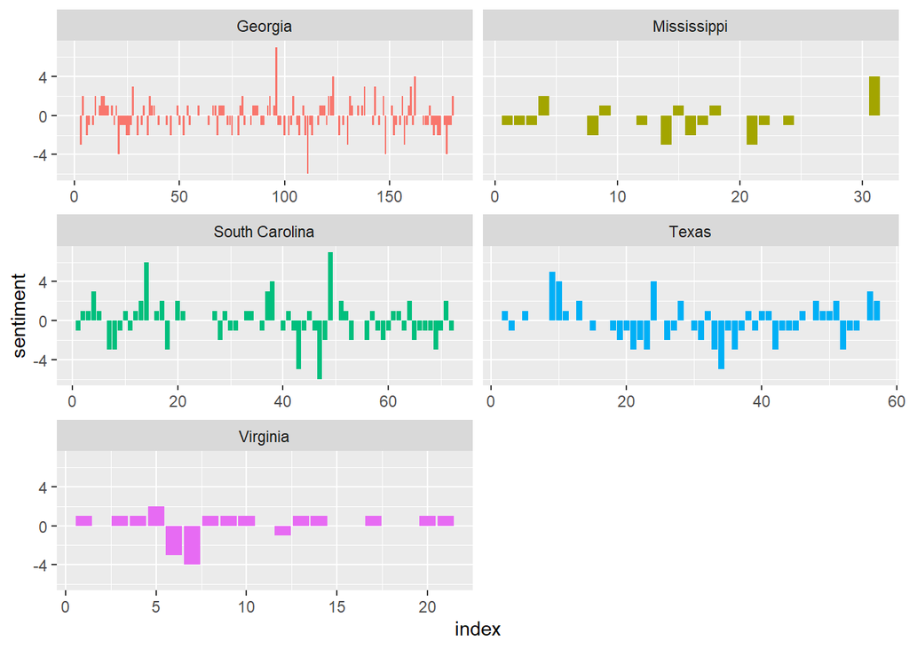

| line | state | word |
| --- | --- | --- |
| 1 | Georgia | the |
| 1 | Georgia | people |
| 1 | Georgia | of |
| 1 | Georgia | georgia |
| 1 | Georgia | having |
| 1 | Georgia | dissolved |
| 1 | Georgia | their |
| 1 | Georgia | political |
| 1 | Georgia | connection |
| 1 | Georgia | with |

[output cut: 8279 more lines]

| word | lexicon |
| --- | --- |
| a | SMART |
| a's | SMART |
| able | SMART |
| about | SMART |
| above | SMART |
| according | SMART |
| accordingly | SMART |
| across | SMART |
| actually | SMART |
| after | SMART |

[output cut: 1139 more lines]

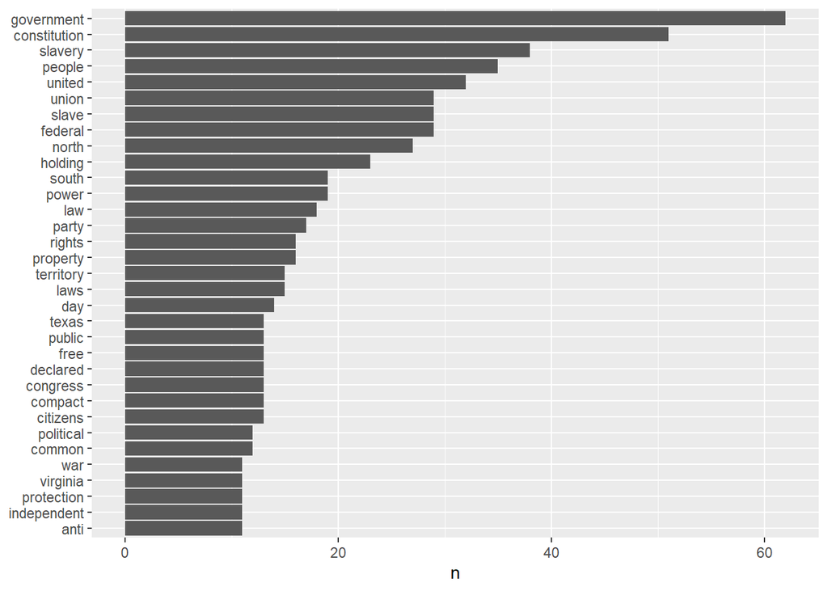

**Individual State Sentiment Analysis**

**NOTE**: To attain a correct result for the Sentiment Analysis, we removed stop words (words that act as transitional words or phrases in sentence structure, but cares for significiant sentiment value.) In doing so, we cut the original content of the Historical documents to their substantive meat (material sentiment), which this allowed for a proper Sentiment Analysis of the historical text. Furthermore, to make the Analysis for accurate and naunced; we broke down the Sentiment Analysis down to each State’s own Declaration of secession, and created individual segments for each respective State’s analysis.

**VIRGINIA**

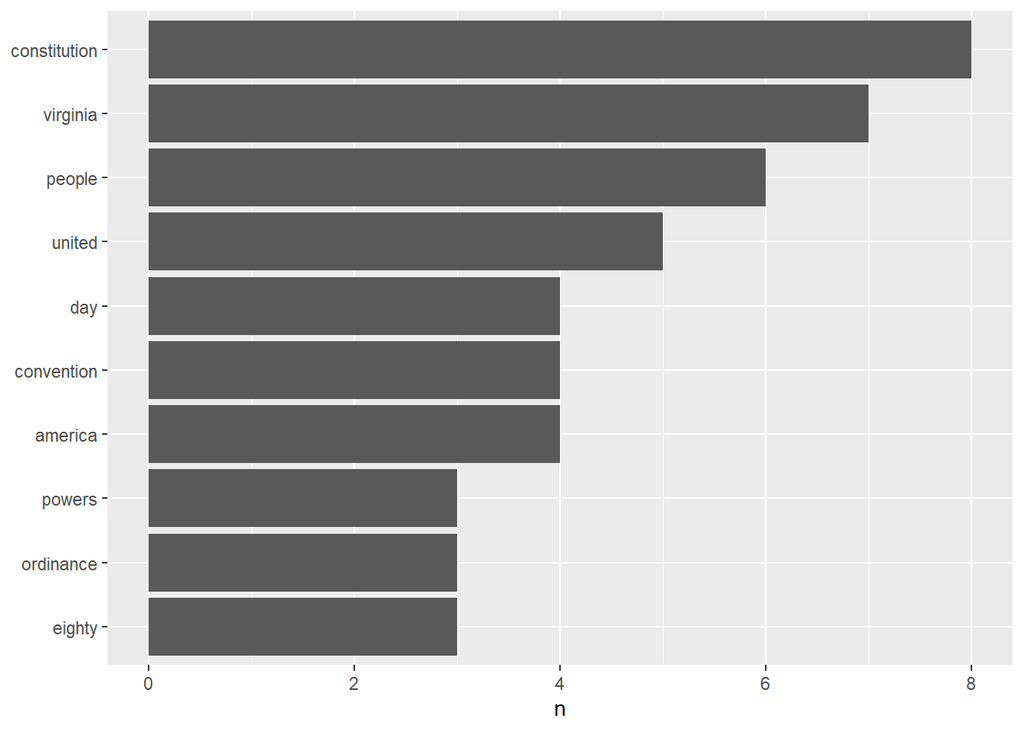

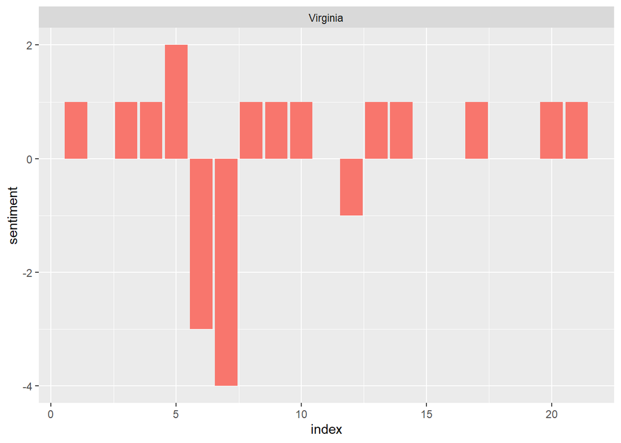

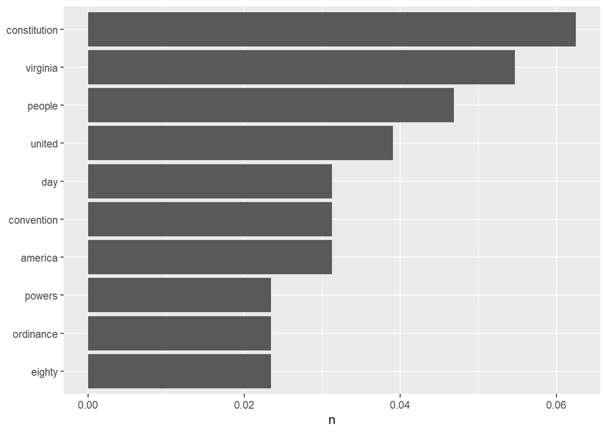

A knitr kable.

| word | n |
| --- | --- |
| constitution | 0.0625000 |
| virginia | 0.0546875 |
| people | 0.0468750 |
| united | 0.0390625 |
| america | 0.0312500 |
| convention | 0.0312500 |
| day | 0.0312500 |
| eighty | 0.0234375 |
| ordinance | 0.0234375 |
| powers | 0.0234375 |

**Analysis:** Scrutiny of the documentation, led to the conclusion that Virgina seperation from the Unon on, April 19, 1861, was motivated by States rights, and state sovereignty.The documentation conveyed the legislative ground work for the dissolution of biding and relations of the declared sovereign State of Virginia and the sovereign state of the United States of America.

**TEXAS**

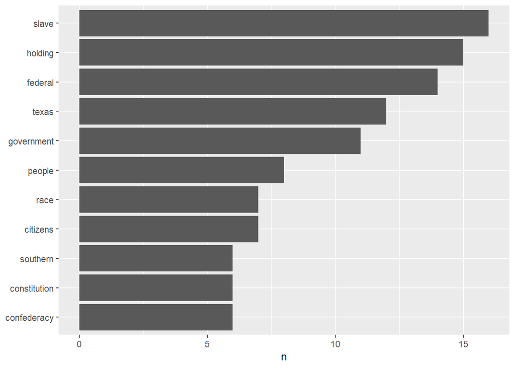

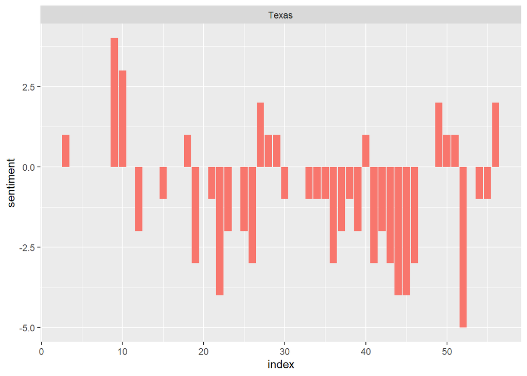

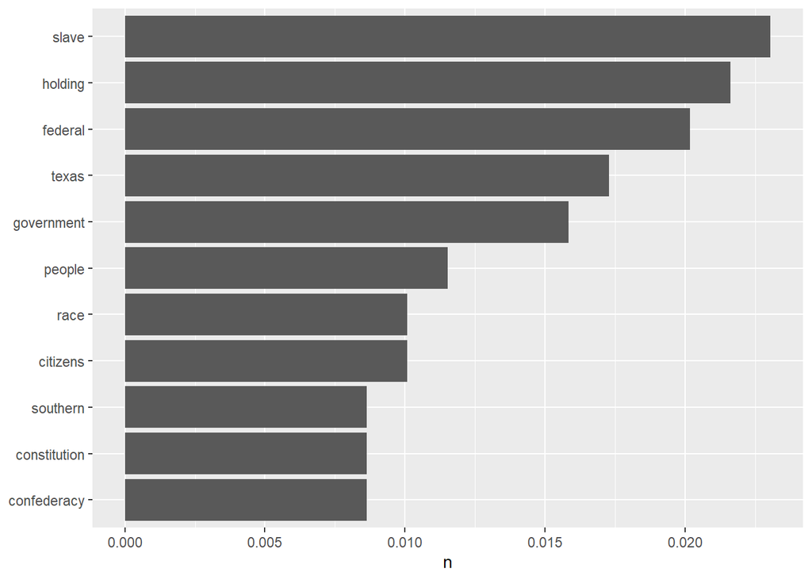

A knitr kable.

| word | n |
| --- | --- |
| slave | 0.0230548 |
| holding | 0.0216138 |
| federal | 0.0201729 |
| texas | 0.0172911 |
| government | 0.0158501 |
| people | 0.0115274 |
| citizens | 0.0100865 |
| race | 0.0100865 |
| confederacy | 0.0086455 |
| constitution | 0.0086455 |
| southern | 0.0086455 |

**Analysis:** The backwater of the South: Texas motion of speration from the Union, came to acceptance by the State Legistlator on, February 1, 1861. The Declaration of cuase based the reasons of the motion upon greivance against the Northern Territories hostile attitude, and policies against Slavery. In conclusion, Texas seceded from the Union solely, based on the Slave issue.

**SOUTH CAROLINA**

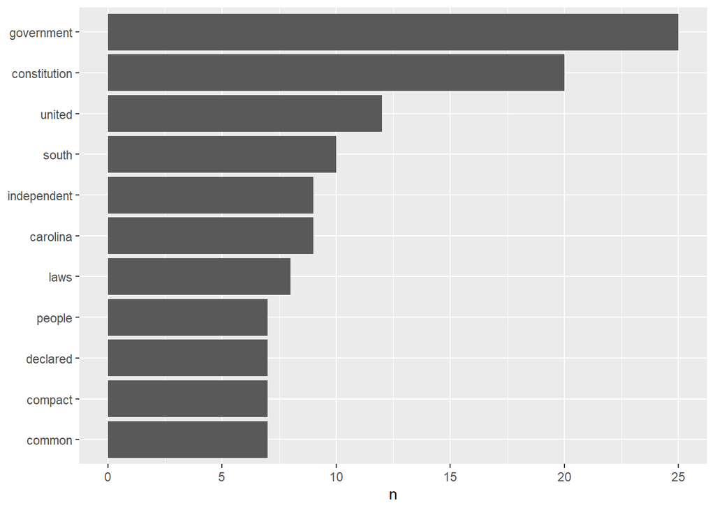

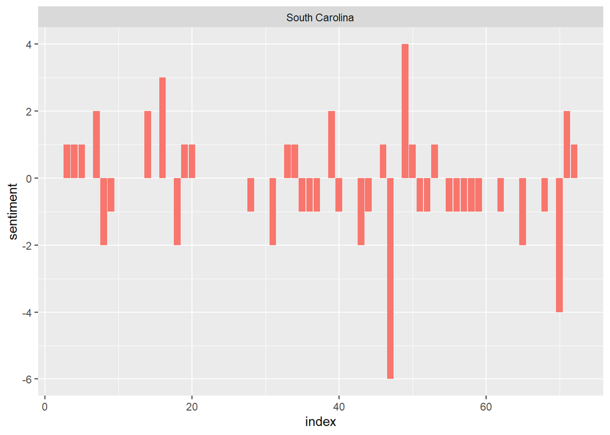

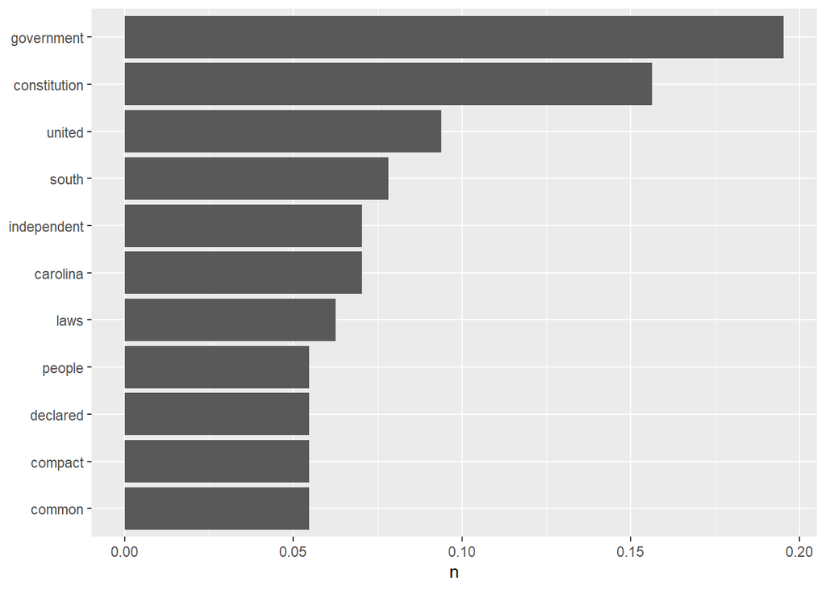

A knitr kable.

| word | n |
| --- | --- |
| government | 0.1953125 |
| constitution | 0.1562500 |
| united | 0.0937500 |
| south | 0.0781250 |
| carolina | 0.0703125 |
| independent | 0.0703125 |
| laws | 0.0625000 |
| common | 0.0546875 |
| compact | 0.0546875 |
| declared | 0.0546875 |
| people | 0.0546875 |

**Analysis:** The first state to led the Secessionist movement prior to the civil War, left the Union on, December 20, 1860; approximately 45 days after Abraham Lincoln was the President-Elect of the United States of America. With further examination, South Carlonia’s motivations to leave the Union were based upon State-rights, and complaints of the Federal Government’s violation against convention that binded the two parties to the constitution, and the constitution itself. The state to have led the Secession movement during the Tariff Crisis of 1828, on the basis of State’s Right, granted under the 10-TH Amendment of the U.S. Constitution, would in fact, try to leave the Union 32 years later, on the same basis, and argument presented to then President Andrew Jackson, then now President Abraham Lincoln.

**MISSISSIPPI**

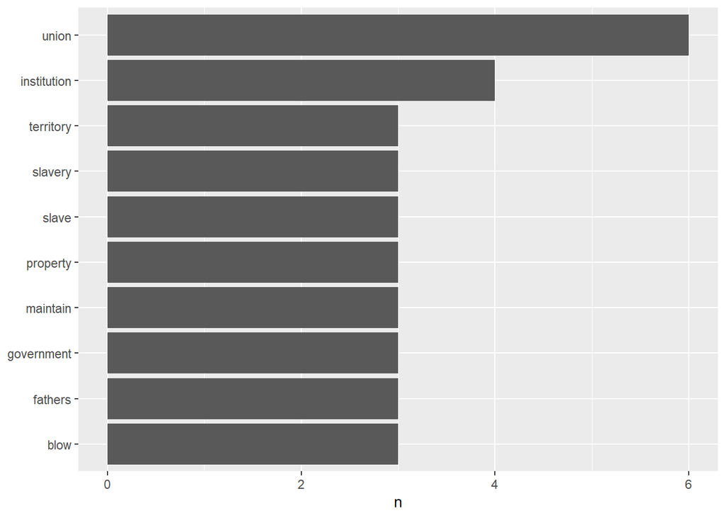

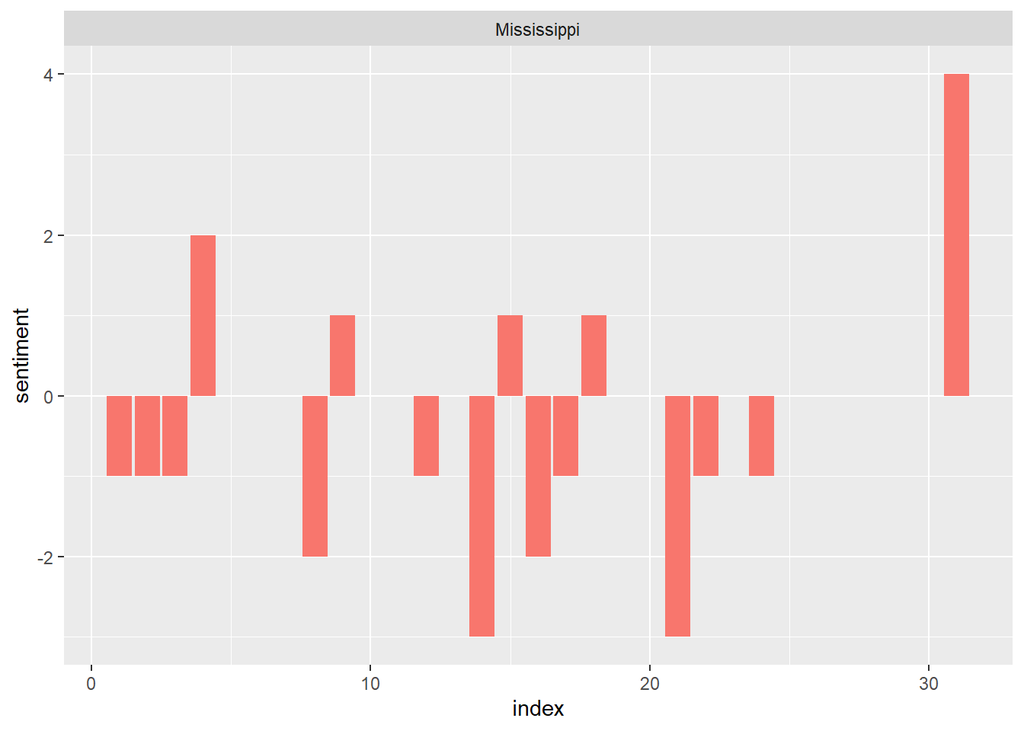

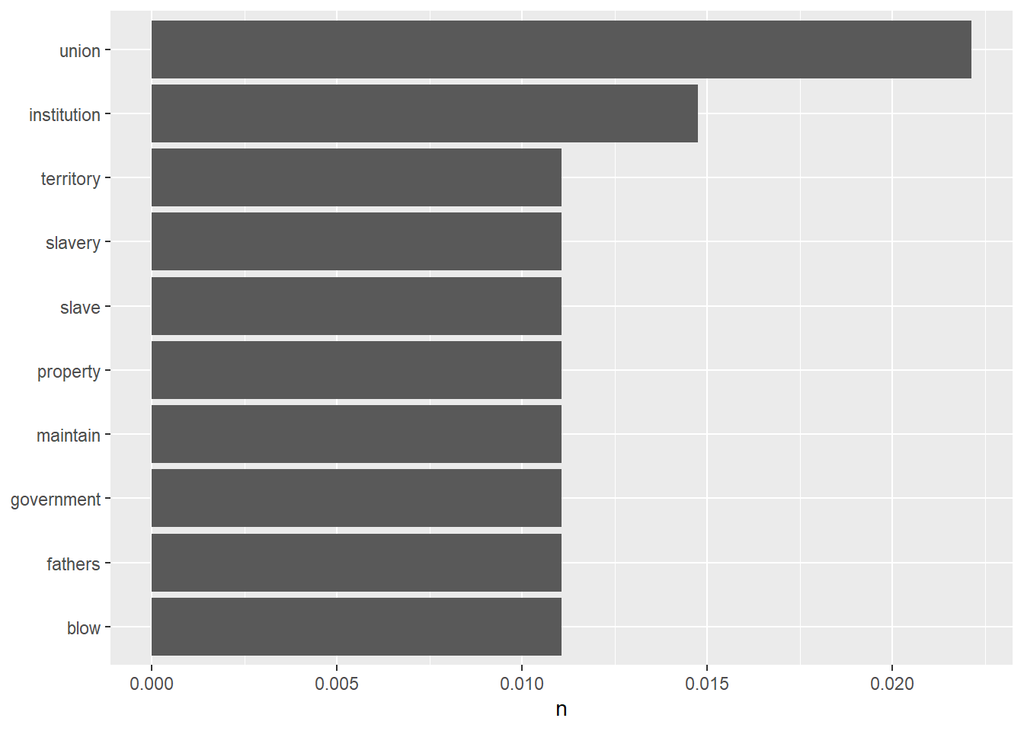

A knitr kable.

| word | n |
| --- | --- |
| union | 0.0221402 |
| institution | 0.0147601 |
| blow | 0.0110701 |
| fathers | 0.0110701 |
| government | 0.0110701 |
| maintain | 0.0110701 |
| property | 0.0110701 |
| slave | 0.0110701 |
| slavery | 0.0110701 |
| territory | 0.0110701 |

**Analysis:** After scrutinizing the text, the motion for the of Mississippi seceded the Union on, January 9, 1861, was motivated directly upon slavery, and gravies lay against the Northern Territories. The author of the declaration, argued that northern aggression, had transgress against the South, and her political and economics interests, with Northern Tarriffs that protected their Industrial Sector of Economy against the foriegn Euporupean Great Powers, has also destoryed the southern attempts of southern-industrialization and manufacturing, forcing the South to further rely upon its economy of Slavery, and an agricultural organization of the South’s Economic basis and society. Thus with the denial of the slave-system to the South by the North, the author argued that the North Action of deniel would underpinned the commercer of the state, and in the author view, the world. And thus, Mississippi sought sessecion from the Union based on Slavery, and Economic devestation that would have resulted from the denial from this system of Economic organization.

**GEORGIA**

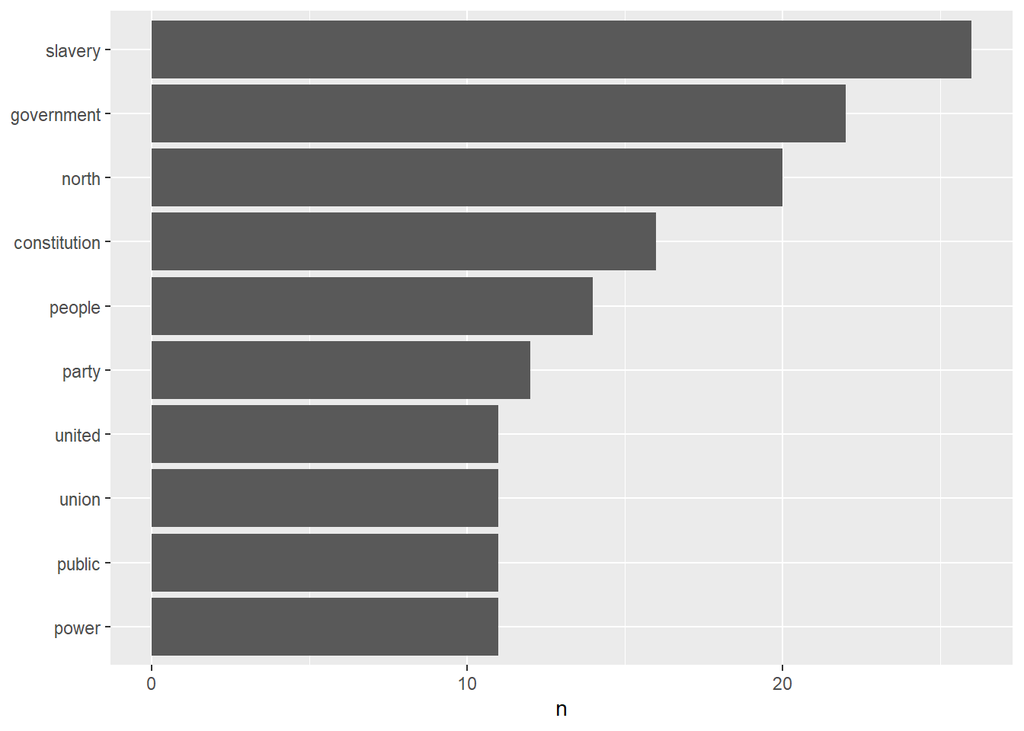

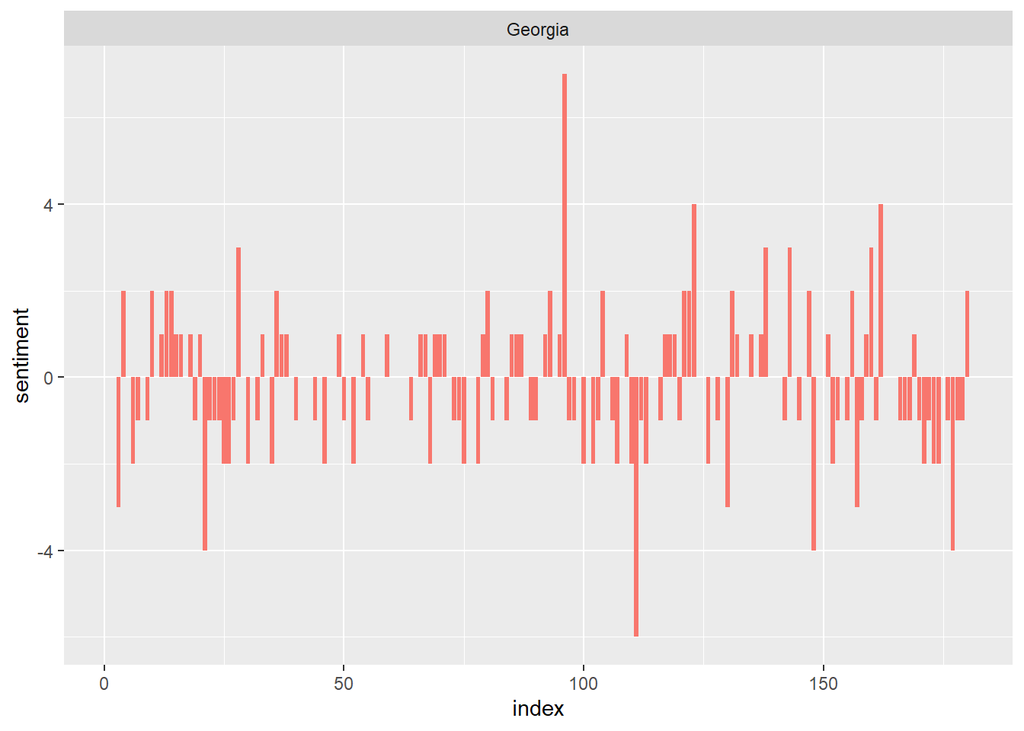

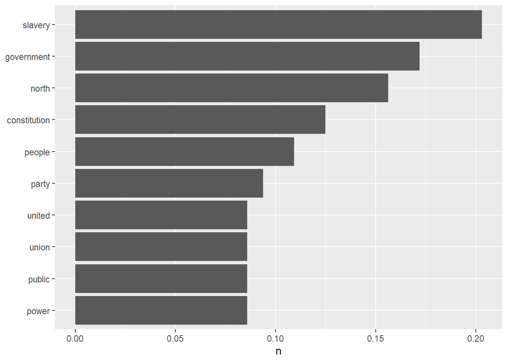

A knitr kable.

| word | n |
| --- | --- |
| slavery | 0.2031250 |
| government | 0.1718750 |
| north | 0.1562500 |
| constitution | 0.1250000 |
| people | 0.1093750 |
| party | 0.0937500 |
| power | 0.0859375 |
| public | 0.0859375 |
| union | 0.0859375 |
| united | 0.0859375 |

**Anaylysis:** The topic of Slavery played a significant role in the political discourse, and declaration that led towards Georgia’s secession motion, to seperate from the Union on January 19, 1861.The authored, Declaration of Causes, cited, grieves against the Northern territories based on their hostiles towards the South, and its respective culture, lifestyle, and underpinned dependence on Algarian slaved-based communities, Of course, this bleed into the second component of Georgia’s greviance towards the North: tarriffs for many decades had underpinned the Protectist policiy of the Northern Whig Parties, and the Federalist parties before them. The economic policy was implemented by Alexander Hamilton, during the Washington administration to raise revenue to finance, and payoff portion of the National Debt. Additionally, Alexander Hamilton used these tarriffs, in similar fashion to other Western economies, to protect domestic industry and manufacturing, against dumping and cometition from state-own monopolies of the Old-World. But course of, this had unintended consequences for the Southern territories of the Union. Unable to sustain a manufacturing based themselves, the southern states had been reliant upon British manufactured goods, and capital for the continued operation of their planation system: without these sources of finished good, the large planations that built the Southern economy would eventually collapse, as small manufacturing would not have been able to compensate from the lost of supply, and thus capital depreciation would led to planation’s lacking capital, and thus, eventually going bankrupt. Peeling back now: As a result southern states, such as Georgia, were forced to rely upn Northern Manufacturing to meet the needs of productive manufactured good, that the tarriff cut-off from Great Briton. This of course, created tension with the South, and North; which eventually rose to feeling of revulsion towards one another, as implicated in the author’s direction mention of this issue in the documentation.

**CONCLUSION**

**Conclusion:** The Civil Wars was fought over a complicate reason: it was not fought over slavery originally, but over the preservation of the Union, and repression of a open-rebellion by the Southern States of the United States. Nonetheless, the war eventually evolved into a War against slavery, this did not occur until the middle of the conflict. Digressing, the Sourthern states had their own independent reasions for Secession. These reason were disguished from one another, but had a similar line of interest - slavery and State rights. Main motivations for Georgia, Mississipi, and Texas secession from the Union during the Civil War were based on Slavery; but on the other hand, south Carolina, and Virginia motivation’s were mainly based on State’s Rights.